# R Notebook

# 00_Loading and installing packages

# Loading data

```r
pig_d <- read_excel("~/SourceData/Pig.xlsx", sheet = "pig_area")
prod <- read_excel("~/SourceData/Pig.xlsx", sheet = "pig_prod")

pig <- select(pig_d, 2:14)

depth <- select(pig_d, 1)
```

# 02_Pigment data exploration

First we clean up the data. Remove nans or 0. In this case, the sample was measure and so the pigments which were not detected are not NaNs, beacuse we know that they are not in the sample. Thus, all NaNs are now replaced with 0es.

```r
pig_filled <- pig %>% replace(is.na(.), 0)

pig_d <- pig_d %>% replace(is.na(.), 0)

# Pig_da.nan<-na.omit(pig_da)
# #pig_filled <- Pig.nan[which(colMeans(=0(Pig.nan)) >= .95)]
#
# remove_high_zero_columns <- function(data) {
#   # Calculate the proportion of zeros in each column
#   prop_zeros <- colMeans(data == 0)
#   # Keep columns with less than or equal to 90% zeros
#   data[, prop_zeros <= 0.5]
# }
# # Remove columns with high zero proportion
# Pig_da.clean <- as.data.frame(remove_high_zero_columns(Pig_da.nan))
#
# pig_filled <- select(Pig_da.clean, 3:22)
```

## K-means clustering

deciding on the number of clusters, with the elbow method

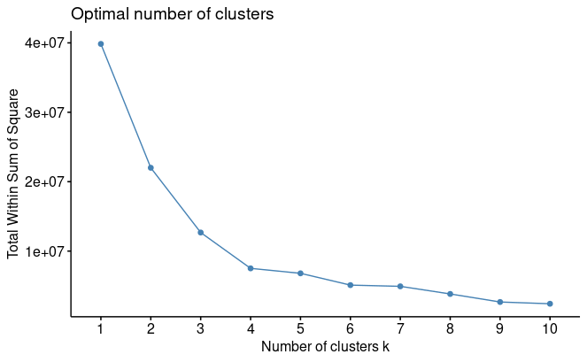

```r
fviz_nbclust(pig_filled, kmeans, method = "wss")
```

Plotting the selected number of clusters on top of the plot

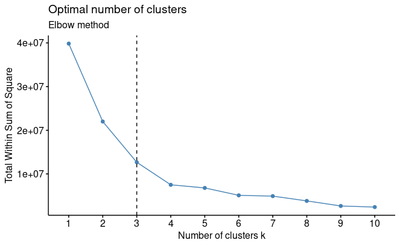

```r
# To save the plot, you can uncomment the first and the last line of this section
#png(filename = "No_clusters_K-means.png", width = 500, height = 500, units = "px", pointsize = 12)

fviz_nbclust(pig_filled, kmeans, method = "wss") + geom_vline(xintercept = 3, linetype = 2)+
  #here you can add the number of clusters to be shown in with a line
  labs(subtitle = "Elbow method")
```

```r
#dev.off()
```

### K-means clustering

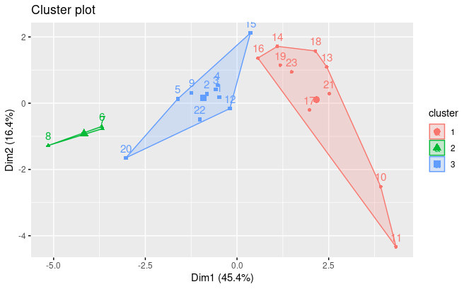

```r
#make this example reproducible
set.seed(100)
#perform k-means clustering with k = 5 clusters
km <- kmeans(pig_filled, centers = 3, nstart = 25)

#plot results of final k-means model

#To save the plot, you can uncomment the first and the last line of this section
#png(filename = "K-means_clusters.png", width = 500, height = 500, units = "px", pointsize = 12)
fviz_cluster(km, data = pig_filled)
```

```r
#dev.off()
```

```r
#LR
cluster_assignments <- km$cluster
df_clustered <- bind_cols(pig_d, cluster_assignments)
colnames(df_clustered)[15] <- 'K_means_cluster' #this may need to be changed depending on the number of pigments
```

## Hierarchical unconstrained clustering

Standardizing the data for clustering

```r
data <- as.matrix(pig_filled)
# Standardise data for CLUSTER analysis, z-scoring
data_standardized <- data
for(i in 1:ncol(data_standardized) ) {
  data_standardized[ , i] <- data_standardized[,i]/sd(data_standardized[,i])
  }
```

```r
# Compute hierarchical clustering
res.hc <- data_standardized %>% scale() %>%
# Scale the data
dist(method = "euclidean") %>%
  # Compute dissimilarity matrix
  hclust(method = "ward.D2")
# Compute hierachical clustering
```

Visualize the clusters using dendrogram

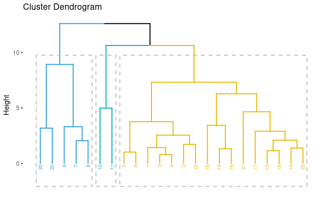

```r
# Visualize using factoextra
# Cut in x groups and color by groups

#To save the plot, you can uncomment the first and the last line of this section
# png(filename = "~/work/holzmaar/figs/Pigments_Hclust_dendrogram.png", width = 800, height = 500, units = "px", pointsize = 12)

fviz_dend(res.hc, k = 3, # Cut in four groups
          cex = 0.5, # label size
          k_colors = c("#2E9FDF", "#00AFBB", "#E7B800", "#FC4E07","#6e57d2" ), color_labels_by_k = TRUE, # color labels by groups
          rect = TRUE # Add rectangle around groups
          )
```

```r
# dev.off()
```

Save the clusters to your dataset

```r
#LR
clust <- hclust(dist(data_standardized, method="euclidean"), method="ward.D2")
clustercut<-cbind(1:23,cutree(clust,3)) #fill in the number of observations (rows) and number of clusters acooriding to the dendrogram
df_clustered <- bind_cols(df_clustered, clustercut)
colnames(df_clustered)[16] <- 'order' # change the column number based on your dataset size
colnames(df_clustered)[17] <- 'Hcluster' # change the column number based on your dataset size
```

## Hierarchical constrained clustering CONISS

Standardize data before CONISS clustering

```r
data <- as.matrix(pig_filled)
# Standardise data for CLUSTER analysis
data_standardized <- data
for(i in 1:ncol(data_standardized) ) {
  data_standardized[ , i] <- data_standardized[,i]/sd(data_standardized[,i])
  }
```

### Compute hierarchical clustering

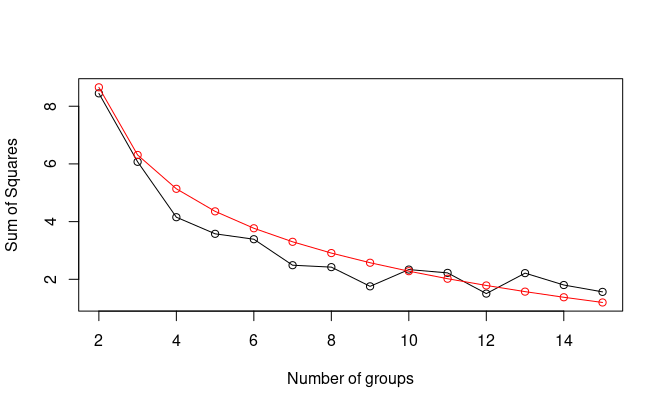

```r
bstick(chclust(dist(data_standardized, method="euclidean"), method="coniss"), 15)
```

### Cluster

```r
#Dendrogram classic
clust <- chclust(dist(data_standardized, method="euclidean"), method="coniss")
#plot(clust, hang=-1, horiz=FALSE, x.rev=TRUE, cex= 0.8)
```

### Visualize dendrogram

```r
plot(clust, hang=-1, horiz=FALSE, x.rev=TRUE, cex= 0.8)
# Number of clusters
k <- 3
groups <- cutree(clust, k=k)
rect.hclust(clust, k=k, border="red")
```

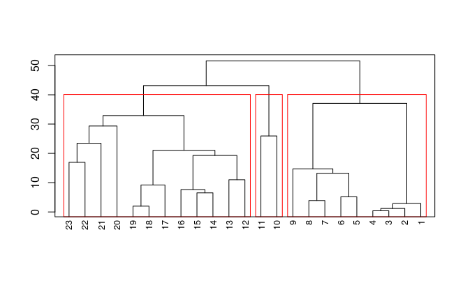

```r
box(lty="solid")
```

```r
data.clust<-cbind(data,groups)
t <- as.data.frame(groups)
```

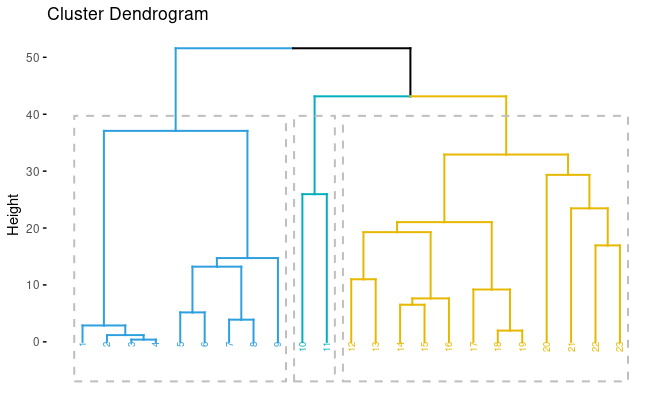

```r
# Visualize using factoextra
# Cut in 4 groups and color by groups
#quartz()

#To save the plot, you can uncomment the first and the last line of this section
# png(filename = "~/work/holzmaar/figs/Pigments_CONISS_dendrogram.png", width = 800, height = 500, units = "px", pointsize = 12)

fviz_dend(clust, k = 3, # Cut in four groups
          cex = 0.5, # label size
          k_colors = c("#2E9FDF", "#00AFBB", "#E7B800", "#FC4E07","#6e57d2", "yellow", "green", "black"), color_labels_by_k = TRUE, # color labels by groups
          rect = TRUE # Add rectangle around groups
          )
```

```r
# dev.off()
```

Save the clusters to your dataset

```r
#pigment data
cluster <- chclust(dist(data_standardized, method="euclidean"), method="coniss")
clustercut<-cbind(1:23,cutree(cluster,3))
df_clustered <- bind_cols(df_clustered, clustercut)
colnames(df_clustered)[18] <- 'orderCONISS'
colnames(df_clustered)[19] <- 'CONISScluster'
```

Get the file with assigned clusters for further plotting

```r
# Get a table with the content of each cluster
#write.table(clustercut, "Pig_unconstrained_table_with_clusters_3.txt", sep="\t") #
# write.xlsx(HR_cluster_all, "data/HR_all_clustered.xlsx", rowNames = FALSE)
#low resolution
write.xlsx(df_clustered, "~/Pig_clustered.xlsx", rowNames = FALSE, col_type ="numeric")
```